# USA today diversity

Shenghao Wu

March 4, 2020

### The USA Today Diversity Index

The USA TODAY Diversity Index is a number – on a scale from 0 to 100 – that represents the chance that two people chosen randomly from an area will be different by race and ethnicity. In more personal terms: “What is the chance that the next person I meet will be different from me?” A higher number means more diversity, a lower number, less. The index was invented in 1991 by Phil Meyer of the University of North Carolina and Shawn McIntosh of USA TODAY.

#### Exploratory Analysis

1. At what level (State, County, City) is the American Community Survey data available? How is this different than the deccenial census?

**Answer:** American Community Survey data is different from decennial Census data in that ACS data are based on an annual sample of approximately 3 million households, rather than a more complete enumeration of the US population, as for the geographic difference, there are state, county, city information in acs, while in decennial census data, there is only MCD including town and city data.

2. What variable and variable codes are available to describe race and ethnicity in the US Census? Describe how these variables are represented in the data (Variables: B2001_001-B2001_006 & B03002_001-B03002_002 & B03002_012).

3. How does the American Community Survey define race and ethnicity? Is this important information to report under assumptions for your analysis?

**Answer:** Each variable stands for one race and ethnicity, In the current federal scheme, there are five named races – white, black/African-American, American Indian/Alaska Native, Asian and Native Hawaiian/Other Pacific Islander. The Census also includes a category called “Some other race.” Because studies show that people who check it are overwhelmingly Hispanic. This information is kind of useful, with it we can confirm all the races have been included.

4. Does the American Community Survey provide the margin of error for their estimates of the proportion of the prevalence of each race and ethnicity? How might this impact the validity of our results?

**Answer:** Margins of error (MOE) are provided for every American Community Survey (ACS) estimate. So when we estimate we also need to calculate MOE in and show them up in our results. Also we need to tell readers that 90% confidence level is the Census Bureau Standard

5. Use the *tidycensus* API to assign the race and ethnicity data for New York, New Jersey and Connecticut (at the County level) to a data frame.

```r
library(tidycensus)
library(tidyverse)
library(sf)
library(leaflet)
#get api from the website, using variable names to get data
census_api_key("aade56b98343272d7fc23c5281472fd33b2ec70d"， install = FALSE)
```

```
## To install your API key for use in future sessions, run this function with `install = TRUE`.
```

```r
aca <- get_acs(geography = "county",
              year = 2017,
              variables = c(total="B02001_001",
                            white="B02001_002",
                            black="B02001_003",
                            indian="B02001_004",
                            asian="B02001_005",
                            hawa="B02001_006",
                            tohispanic="B03002_001",
                            nohispanic="B03002_002",
                            ishispanic="B03002_012"),
              state = c("36","34","09"),
              survey = "acs5",
              geometry = TRUE)
aca
```

```
## Simple feature collection with 819 features and 5 fields
## geometry type:  MULTIPOLYGON
## dimension:      XY
## bbox:           xmin: -79.76215 ymin: 38.92852 xmax: -71.78699 ymax: 45.01585
## epsg (SRID):    4269
## proj4string:    +proj=longlat +datum=NAD83 +no_defs
## First 10 features:
##    GEOID                          NAME   variable estimate  moe
## 1  09001 Fairfield County, Connecticut      total   947328   NA
## 2  09001 Fairfield County, Connecticut      white   696286 2866
## 3  09001 Fairfield County, Connecticut      black   107305 1494
## 4  09001 Fairfield County, Connecticut     indian     2527  557
## 5  09001 Fairfield County, Connecticut      asian    48962  829
## 6  09001 Fairfield County, Connecticut       hawa      396  147
## 7  09001 Fairfield County, Connecticut tohispanic   947328   NA
## 8  09001 Fairfield County, Connecticut nohispanic   766949   NA
## 9  09001 Fairfield County, Connecticut ishispanic   180379   NA
## 10 09003  Hartford County, Connecticut      total   897417   NA
##                          geometry
## 1  MULTIPOLYGON (((-73.36424 4...
## 2  MULTIPOLYGON (((-73.36424 4...
## 3  MULTIPOLYGON (((-73.36424 4...
## 4  MULTIPOLYGON (((-73.36424 4...
## 5  MULTIPOLYGON (((-73.36424 4...
## 6  MULTIPOLYGON (((-73.36424 4...
## 7  MULTIPOLYGON (((-73.36424 4...
## 8  MULTIPOLYGON (((-73.36424 4...
## 9  MULTIPOLYGON (((-73.36424 4...
## 10 MULTIPOLYGON (((-73.02054 4...
```

```r
#Don't need data in moe this column so I delete it
aca <- select(aca, -moe)
aca
```

```
## Simple feature collection with 819 features and 4 fields
## geometry type:  MULTIPOLYGON
## dimension:      XY
## bbox:           xmin: -79.76215 ymin: 38.92852 xmax: -71.78699 ymax: 45.01585
## epsg (SRID):    4269
## proj4string:    +proj=longlat +datum=NAD83 +no_defs
## First 10 features:
##    GEOID                          NAME   variable estimate
## 1  09001 Fairfield County, Connecticut      total   947328
## 2  09001 Fairfield County, Connecticut      white   696286
## 3  09001 Fairfield County, Connecticut      black   107305
## 4  09001 Fairfield County, Connecticut     indian     2527
## 5  09001 Fairfield County, Connecticut      asian    48962
## 6  09001 Fairfield County, Connecticut       hawa      396
## 7  09001 Fairfield County, Connecticut tohispanic   947328
## 8  09001 Fairfield County, Connecticut nohispanic   766949
## 9  09001 Fairfield County, Connecticut ishispanic   180379
## 10 09003  Hartford County, Connecticut      total   897417
##                          geometry
## 1  MULTIPOLYGON (((-73.36424 4...
## 2  MULTIPOLYGON (((-73.36424 4...
## 3  MULTIPOLYGON (((-73.36424 4...
## 4  MULTIPOLYGON (((-73.36424 4...
## 5  MULTIPOLYGON (((-73.36424 4...
## 6  MULTIPOLYGON (((-73.36424 4...
## 7  MULTIPOLYGON (((-73.36424 4...
## 8  MULTIPOLYGON (((-73.36424 4...
## 9  MULTIPOLYGON (((-73.36424 4...
## 10 MULTIPOLYGON (((-73.02054 4...
```

```r
#Change the form in spread way so it looks better
aca <- spread(aca, key = variable, value = estimate)
aca
```

```
## Simple feature collection with 91 features and 11 fields
## geometry type:  MULTIPOLYGON
## dimension:      XY
## bbox:           xmin: -79.76215 ymin: 38.92852 xmax: -71.78699 ymax: 45.01585
## epsg (SRID):    4269
## proj4string:    +proj=longlat +datum=NAD83 +no_defs
## First 10 features:
##    GEOID                           NAME  asian  black hawa indian ishispanic
## 1  09001  Fairfield County, Connecticut  48962 107305  396   2527     180379
## 2  09003   Hartford County, Connecticut  45626 121811  279   2592     154977
## 3  09005 Litchfield County, Connecticut   3546   3560    6    330      10510
## 4  09007  Middlesex County, Connecticut   4780   8442    0    265       9612
## 5  09009  New Haven County, Connecticut  34047 112152  168   1165     148446
## 6  09011 New London County, Connecticut  11210  15556   61   1722      27186
## 7  09013    Tolland County, Connecticut   6714   4797    5     48       7860
## 8  09015    Windham County, Connecticut   1565   2617   16    736      12946
## 9  34001    Atlantic County, New Jersey  22902  41259   92    908      50510
## 10 34003      Bergen County, New Jersey 152608  56391  308   1627     176933
##    nohispanic tohispanic  total  white                       geometry
## 1      766949     947328 947328 696286 MULTIPOLYGON (((-73.36424 4...
## 2      742440     897417 897417 644122 MULTIPOLYGON (((-73.02054 4...
## 3      173944     184454 184454 171607 MULTIPOLYGON (((-73.51795 4...
## 4      154498     164110 164110 145791 MULTIPOLYGON (((-72.75294 4...
## 5      713681     862127 862127 641178 MULTIPOLYGON (((-72.76143 4...
## 6      243586     270772 270772 219757 MULTIPOLYGON (((-72.46673 4...
## 7      143736     151596 151596 134422 MULTIPOLYGON (((-72.51733 4...
## 8      103728     116674 116674 103901 MULTIPOLYGON (((-72.25208 4...
## 9      222416     272926 272926 182673 MULTIPOLYGON (((-74.98527 3...
## 10     760987     937920 937920 664406 MULTIPOLYGON (((-74.27066 4...
```

#### Computing The USA Today Diversity Index

Each of the calculations below will be done **by county** and not in aggregate.

**Step 1:**

In the current federal scheme, there are five named races – white, black/African-American, American Indian/Alaska Native, Asian and Native Hawaiian/Other Pacific Islander and an estimate for total population (B2001_001-B2001_006). Ensure that you have collected the proper data from the *tidycensus* API for these values, as well as the values for the Hispanic population (B03002_001-B03002_002 & B03002_012).

Use the *spread* function to create columns for each racial group (and the total population). Rename these columns to better reflect the data if you have not already done so.

Calculate each group’s share of the population. This is done by dividing the value for each racial column by the total population column. Create new variables for your data frame for each calculation.

$$\small RaceProportion_i = \frac{Race_i}{Total_i}$$

```r
aca<-mutate(aca, pwhite = white/total, pasian = asian/total,
              pblack = black/total, pindian = indian/total, phawa = hawa/total,phis=ishispanic/tohispanic,
               pnohis = nohispanic/tohispanic)
aca
```

```
## Simple feature collection with 91 features and 18 fields
## geometry type:  MULTIPOLYGON
## dimension:      XY
## bbox:           xmin: -79.76215 ymin: 38.92852 xmax: -71.78699 ymax: 45.01585
## epsg (SRID):    4269
## proj4string:    +proj=longlat +datum=NAD83 +no_defs
## First 10 features:
##    GEOID                           NAME  asian  black hawa indian ishispanic
## 1  09001  Fairfield County, Connecticut  48962 107305  396   2527     180379
## 2  09003   Hartford County, Connecticut  45626 121811  279   2592     154977
## 3  09005 Litchfield County, Connecticut   3546   3560    6    330      10510
## 4  09007  Middlesex County, Connecticut   4780   8442    0    265       9612
## 5  09009  New Haven County, Connecticut  34047 112152  168   1165     148446
## 6  09011 New London County, Connecticut  11210  15556   61   1722      27186
## 7  09013    Tolland County, Connecticut   6714   4797    5     48       7860
```

[output cut: 25 more lines]

**Step 2:**

Take each racial group’s share of the population, square it and sum the results.

$$\small P(Racial_i) = \sum_{i=1}^{n} RaceProportion_i^2$$

The Census also includes a category called “Some other race.” Because studies show that people who check it are overwhelmingly Hispanic, that category is not used. Hispanics’ effect on diversity is calculated in Step 3.

```r
aca <- mutate(aca, pracial = (pwhite)^2+(pasian)^2+(phawa)^2+(pblack)^2+(pindian)^2)
aca
```

```
## Simple feature collection with 91 features and 19 fields
## geometry type:  MULTIPOLYGON
## dimension:      XY
## bbox:           xmin: -79.76215 ymin: 38.92852 xmax: -71.78699 ymax: 45.01585
## epsg (SRID):    4269
## proj4string:    +proj=longlat +datum=NAD83 +no_defs
## First 10 features:
##    GEOID                           NAME  asian  black hawa indian ishispanic
## 1  09001  Fairfield County, Connecticut  48962 107305  396   2527     180379
## 2  09003   Hartford County, Connecticut  45626 121811  279   2592     154977
## 3  09005 Litchfield County, Connecticut   3546   3560    6    330      10510
## 4  09007  Middlesex County, Connecticut   4780   8442    0    265       9612
## 5  09009  New Haven County, Connecticut  34047 112152  168   1165     148446
## 6  09011 New London County, Connecticut  11210  15556   61   1722      27186
## 7  09013    Tolland County, Connecticut   6714   4797    5     48       7860
```

[output cut: 36 more lines]

**Step 3:**

Because Hispanic origin is a separate Census question, the probability that someone is Hispanic or not must be figured separately. Take the Hispanic and non-Hispanic percentages of the population, square each and add them to get the chance that any two people will be Hispanic or not. Use this calculation to create a new variable in your data frame.

$$\small P(Ethnic_i) = Hispanic_i^2+ Non Hispanic_i^2$$

```r
aca <- mutate(aca, pethnic = (phis)^2+(pnohis)^2)
aca
```

```
## Simple feature collection with 91 features and 20 fields
## geometry type:  MULTIPOLYGON
## dimension:      XY
## bbox:           xmin: -79.76215 ymin: 38.92852 xmax: -71.78699 ymax: 45.01585
## epsg (SRID):    4269
## proj4string:    +proj=longlat +datum=NAD83 +no_defs
## First 10 features:
##    GEOID                           NAME  asian  black hawa indian ishispanic
## 1  09001  Fairfield County, Connecticut  48962 107305  396   2527     180379
## 2  09003   Hartford County, Connecticut  45626 121811  279   2592     154977
## 3  09005 Litchfield County, Connecticut   3546   3560    6    330      10510
## 4  09007  Middlesex County, Connecticut   4780   8442    0    265       9612
## 5  09009  New Haven County, Connecticut  34047 112152  168   1165     148446
## 6  09011 New London County, Connecticut  11210  15556   61   1722      27186
## 7  09013    Tolland County, Connecticut   6714   4797    5     48       7860
```

[output cut: 36 more lines]

**Step 4:**

To calculate whether two people are the same on both measures, multiply the results of the first two steps. Use this calculation to create a new column in your data frame. This is the probability that any two people are the SAME by race and ethnicity.

$$\small P(Same_i) = P(Racial_i) \times P(Ethnic_i)$$

```r
aca <- mutate(aca, psame = pracial * pethnic)
aca
```

```
## Simple feature collection with 91 features and 21 fields
## geometry type:  MULTIPOLYGON
## dimension:      XY
## bbox:           xmin: -79.76215 ymin: 38.92852 xmax: -71.78699 ymax: 45.01585
## epsg (SRID):    4269
## proj4string:    +proj=longlat +datum=NAD83 +no_defs
## First 10 features:
##    GEOID                           NAME  asian  black hawa indian ishispanic
## 1  09001  Fairfield County, Connecticut  48962 107305  396   2527     180379
## 2  09003   Hartford County, Connecticut  45626 121811  279   2592     154977
## 3  09005 Litchfield County, Connecticut   3546   3560    6    330      10510
## 4  09007  Middlesex County, Connecticut   4780   8442    0    265       9612
## 5  09009  New Haven County, Connecticut  34047 112152  168   1165     148446
## 6  09011 New London County, Connecticut  11210  15556   61   1722      27186
## 7  09013    Tolland County, Connecticut   6714   4797    5     48       7860
```

[output cut: 36 more lines]

**Step 5:**

Subtract the result from 1 to get the chance that two people are different – diverse. For ease of use, multiply the result by 100 to place it on a scale from 0 to 100. Create a new column with your USA Today Diversity Index value.

$$\small DiversityIndex_i = \Big( 1 - P(Same_i) \Big) \times 100$$

```r
aca <- mutate(aca, div = (1 - (psame))*100)
aca
```

```
## Simple feature collection with 91 features and 22 fields
## geometry type:  MULTIPOLYGON
## dimension:      XY
## bbox:           xmin: -79.76215 ymin: 38.92852 xmax: -71.78699 ymax: 45.01585
## epsg (SRID):    4269
## proj4string:    +proj=longlat +datum=NAD83 +no_defs
## First 10 features:
##    GEOID                           NAME  asian  black hawa indian ishispanic
## 1  09001  Fairfield County, Connecticut  48962 107305  396   2527     180379
## 2  09003   Hartford County, Connecticut  45626 121811  279   2592     154977
## 3  09005 Litchfield County, Connecticut   3546   3560    6    330      10510
## 4  09007  Middlesex County, Connecticut   4780   8442    0    265       9612
## 5  09009  New Haven County, Connecticut  34047 112152  168   1165     148446
## 6  09011 New London County, Connecticut  11210  15556   61   1722      27186
## 7  09013    Tolland County, Connecticut   6714   4797    5     48       7860
```

[output cut: 36 more lines]

```r
# here I create column NAMEADIV for question 9
aca$NAMEADIV <- paste(aca$div,aca$NAME)
aca
```

```
## Simple feature collection with 91 features and 23 fields
## geometry type:  MULTIPOLYGON
## dimension:      XY
## bbox:           xmin: -79.76215 ymin: 38.92852 xmax: -71.78699 ymax: 45.01585
## epsg (SRID):    4269
## proj4string:    +proj=longlat +datum=NAD83 +no_defs
## First 10 features:
##    GEOID                           NAME  asian  black hawa indian ishispanic
## 1  09001  Fairfield County, Connecticut  48962 107305  396   2527     180379
## 2  09003   Hartford County, Connecticut  45626 121811  279   2592     154977
## 3  09005 Litchfield County, Connecticut   3546   3560    6    330      10510
## 4  09007  Middlesex County, Connecticut   4780   8442    0    265       9612
## 5  09009  New Haven County, Connecticut  34047 112152  168   1165     148446
## 6  09011 New London County, Connecticut  11210  15556   61   1722      27186
## 7  09013    Tolland County, Connecticut   6714   4797    5     48       7860
```

[output cut: 47 more lines]

#### Geo-spatial Analysis and Visualization

Be sure to properly label your plots and axes. Points will be deducted for incorrect plot titles or axes.

6. Create a histogram of USA Today Diversity Index values. Describe the shape of the histogram in statistical terms (Hint: skewness).

**Answer:**

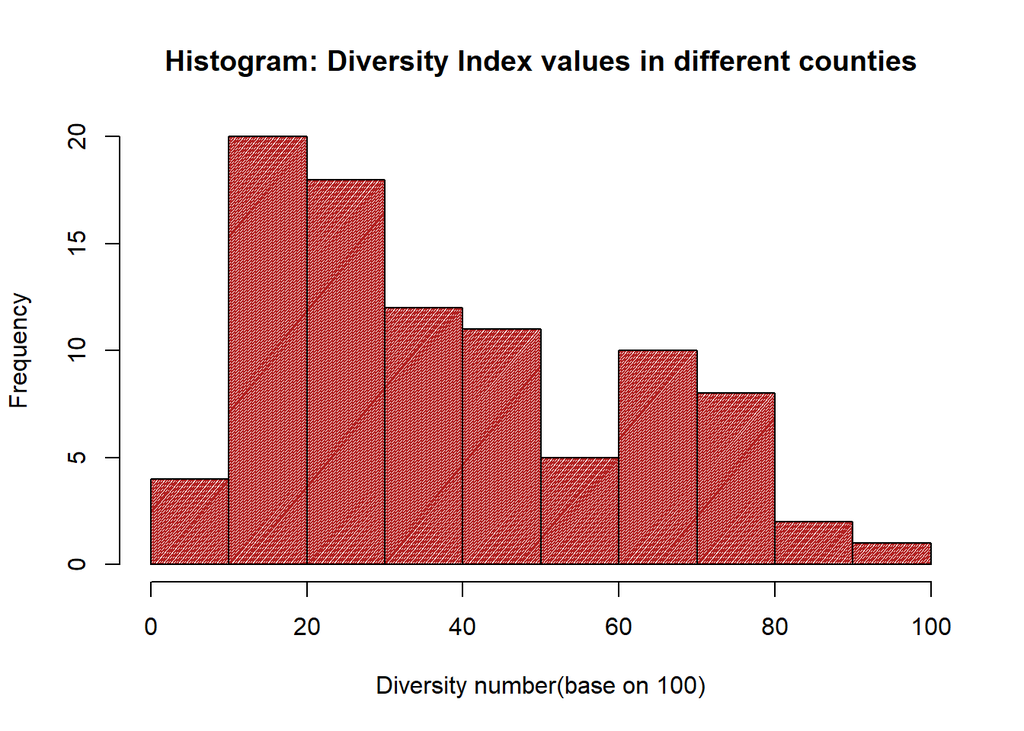

```r
# used hist function to create this paragraph
hist(aca$div, main = "Histogram: Diversity Index values in different counties",
     xlab = "Diversity number(base on 100)", ylab = "Frequency",
     col = "firebrick", density = 75,
     angle = 50, border = "black")
```

```r
#The shape of the histogram is right-skewed`
```

7. Create a visualization which compares the top 10 counties and their diversity index value using ggplot2.

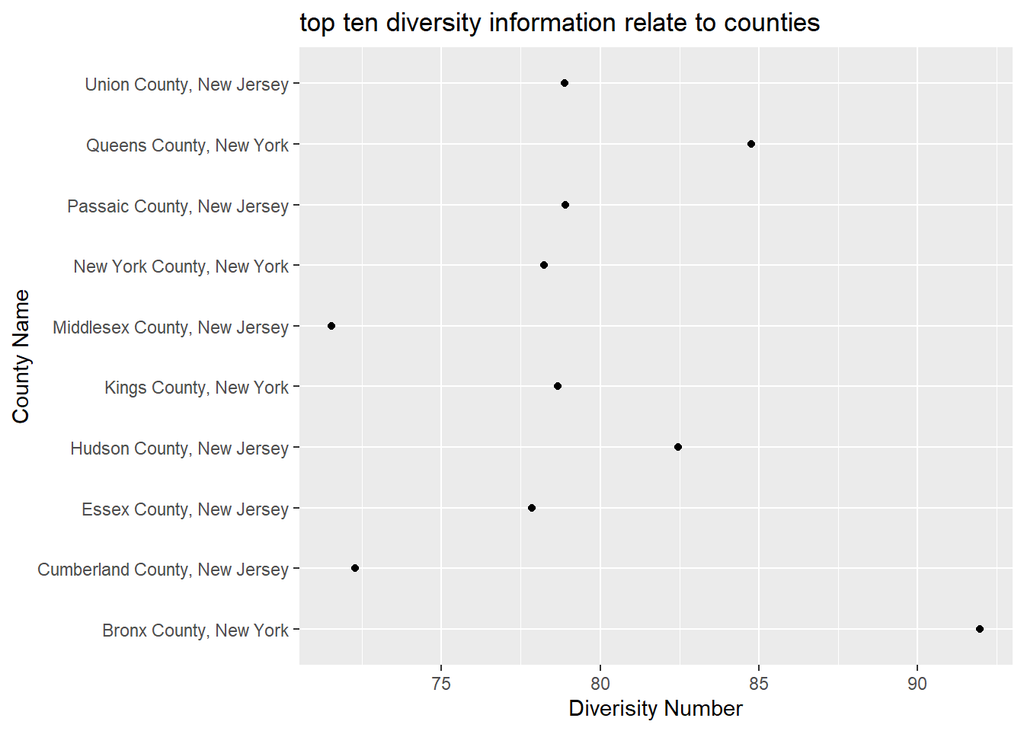

```r
attach(aca)
newdata <- aca[order(-div),]
# here because we just need top 10 counties data
newdata2 <- head(newdata,10)

ggplot(data = newdata2) +
  geom_point(mapping =  aes(x = div, y = NAME))+
  labs(title="top ten diversity information relate to counties", x= "Diverisity Number", y= "County Name")
```

8. Using the *leaflet* mapping library for R (or another mapping library of your choice), visualize the USA Today Diversity Index by county for New York, New Jersey and Connecticut.

```r
library(tidycensus)
library(leaflet)
library(stringr)
library(sf)

pal <- colorQuantile(palette = "viridis", domain = aca$div, n = 10)

map<-aca %>%
    st_transform(crs = "+init=epsg:4326") %>%
    leaflet(width = "100%") %>%
    addProviderTiles(provider = "CartoDB.Positron") %>%
    addPolygons(popup = ~ str_extract(NAME, "^([^,]*)"),
                stroke = FALSE,
                smoothFactor = 0,
                fillOpacity = 0.7,
                color = ~ pal(div)) %>%
    addTiles() %>%
    addLegend("bottomright",
              pal = pal,
              values = ~ div,
              title = "diversition percentiles",
              opacity = 1)

map
```

[interactive chart not shown]

9. Display the following data in the “tooltip” when mousing over your plot: USA Today Diversity Index Value and County Name.

```r
# comparing to question 8, I add label = ~NAMEADIV to make that column information show up
pal <- colorQuantile(palette = "viridis", domain = aca$div, n = 10)

map<-aca %>%
    st_transform(crs = "+init=epsg:4326") %>%
    leaflet(width = "100%") %>%
    addProviderTiles(provider = "CartoDB.Positron") %>%
    addPolygons(popup = ~ str_extract(NAME, "^([^,]*)"),
                stroke = FALSE,
                label = ~NAMEADIV,
                smoothFactor = 0,
                fillOpacity = 0.7,
                color = ~ pal(div)) %>%
    addTiles() %>%
    addLegend("bottomright",
              pal = pal,
              values = ~ div,
              title = "diversition percentiles",
              opacity = 1)

map
```

[interactive chart not shown]

10. Does there appear to be any relationship between geography and diversity? Which state appears to be the most diverse?

**Answer:** Yes, this are relationships. It seems like diversity around NewYork states is the most diverse state